# Community detection for coarse-graining clusters of mosquito habitats

### Coarse graining the network

We can also aggregate together all nodes in each community into a single “metapopulation” node, and sum over all edges between the nodes

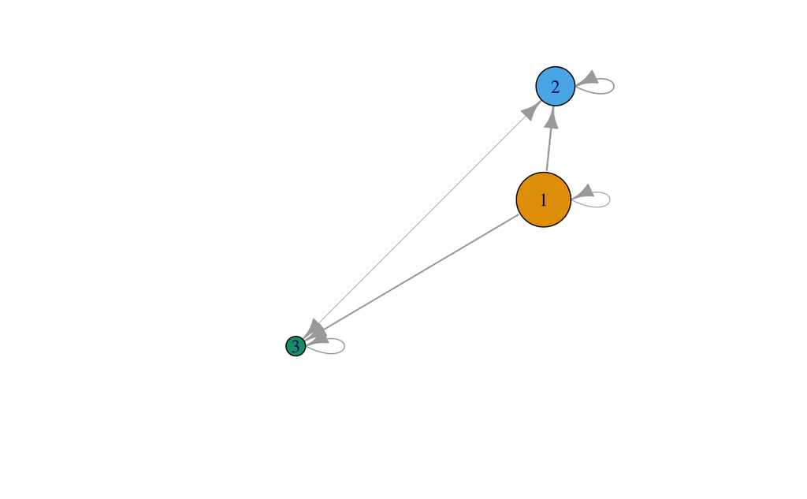

```r
# This maps nodes onto their communities
m <- membership(walk.c)
k <- length(unique(m))
coarse.grain <- array(0, dim = c(k,k))
for (i in seq(1,length(E(qnet.n)))) {
  xy <- ends(qnet.n, E(qnet.n)[i]);
  w <- E(qnet.n)$weight[i];
  coarse.grain[m[xy[1]],m[xy[2]]] = coarse.grain[m[xy[1]],m[xy[2]]] + w}
cg.net <- graph_from_adjacency_matrix(coarse.grain, weighted = TRUE, mode = "directed")
plot(cg.net, edge.width = (E(cg.net)$weight)^.2,# edge.arrow.size = (E(cg.net)$weight)^.2/2,
     vertex.color = c(1:k), vertex.size = 3*matrix(table(membership(walk.c))))
```

### InfoMap algorithm

```r
info.c <- cluster_infomap(qnet.c, e.weights = edge_attr(qnet.c)$weight, modularity = FALSE)
```

[output not shown]

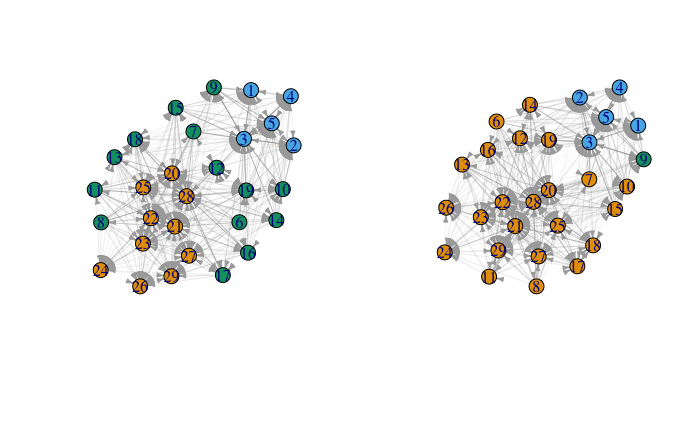

```r
par(mfrow=c(1,2))
# Visualize the networks
plot(qnet.n,
     vertex.color = info.c$membership,
     edge.arrow.size = E(qnet.n)$weight*2, edge.width = E(qnet.n)$weight*5
     )
plot(qnet.n,
     vertex.color = info.q$membership,
     edge.arrow.size = E(qnet.n)$weight*2, edge.width = E(qnet.n)$weight*5
     )
```

So, if we use the full weighted adjacency matrix Q, we end up combining the egg-laying sites in the lower right (a source for mosquitoes) with the egg-laying sites in the upper right (a sink for mosquitoes). This result could reflect the fact that the majority of mosquitoes from the lower right end up in the upper right, but unfortunately conceals the net flow between those two regions in our landscape. I’d say that, for this artificial landscape at least, using C to describe the connected clusters and using N to find the net flows between those clusters gives the best clarity in terms of understanding the different relevant components of the landscape.

In practice, it will probably best to use all three of these clustering schemes when we are confronted with landscapes whose clusters are not straightforward and known ahead of time.